# lab2

Repo: https://github.com/vinampud/gsb544/tree/main/lab2

**0. Import the data and declare your package dependencies.**

```python
%echo
import os
import pandas as pd
import numpy as np
from plotnine import *

os.chdir("C:/Users/ivpri/gsb544/lab2")
avocado_data = pd.read_csv("../data/avocado-updated-2020.csv")
```

```
ECHO is on.
```

**1. Briefly describe the data set. What information does it contain?**

This dataset contains information about national avocado sales specifically for Haas avocados, through channels like grocery, club, dollar, etc. The data contains date of observation, average price per unit/avocado, total number sold, three different PLU columns each pertaining to a different size, and how many avocados under that number were sold, and the number of bags sold per size, year, the type, and region of the observation.

**2. Clean the data in any way you see fit.**

```python
avocado_clean = avocado_data.copy()

major5_map = {
    # Northeast
    "Albany": "Northeast",
    "Baltimore/Washington": "Northeast",   # treating Mid-Atlantic as Northeast
    "Boston": "Northeast",
    "Buffalo/Rochester": "Northeast",
    "Harrisburg/Scranton": "Northeast",
    "Hartford/Springfield": "Northeast",
    "New York": "Northeast",
    "Northeast": "Northeast",
    "Northern New England": "Northeast",
    "Philadelphia": "Northeast",
    "Pittsburgh": "Northeast",
    "Syracuse": "Northeast",

    # Southeast
    "Atlanta": "Southeast",
    "Charlotte": "Southeast",
    "Jacksonville": "Southeast",
    "Louisville": "Southeast",
    "Miami/Ft. Lauderdale": "Southeast",
    "Midsouth": "Southeast",               # TN/AR/MS/KY cluster → Southeast
    "Nashville": "Southeast",
    "New Orleans/Mobile": "Southeast",
    "Orlando": "Southeast",
    "Raleigh/Greensboro": "Southeast",
    "Richmond/Norfolk": "Southeast",
    "Roanoke": "Southeast",
    "South Carolina": "Southeast",
    "Southeast": "Southeast",
    "Tampa": "Southeast",

    # Midwest
    "Chicago": "Midwest",
    "Cincinnati/Dayton": "Midwest",
    "Columbus": "Midwest",
    "Detroit": "Midwest",
    "Grand Rapids": "Midwest",
    "Great Lakes": "Midwest",
    "Indianapolis": "Midwest",
    "Plains": "Midwest",
    "St. Louis": "Midwest",

    # Southwest
    "Dallas/Ft. Worth": "Southwest",
    "Houston": "Southwest",
    "Phoenix/Tucson": "Southwest",
    "South Central": "Southwest",          # TX/OK/LA/AR cluster → Southwest
    "West Tex/New Mexico": "Southwest",

    # West
    "Boise": "West",
    "California": "West",
    "Denver": "West",
    "Las Vegas": "West",
    "Los Angeles": "West",
    "Portland": "West",
    "Sacramento": "West",
    "San Diego": "West",
    "San Francisco": "West",
    "Seattle": "West",
    "Spokane": "West",
    "West": "West",

    # Special (not one of the five)
    "Total U.S.": "National",              # see note below
}

avocado_clean["major_region5"] = avocado_data["geography"].map(major5_map)
```

```python
avocado_clean.isnull().sum()
avocado_clean.rename(columns={"4046": "small-hass", "4225": "large-hass", "4770": "xlarge-hass"}, inplace=True)
```

I cleaned the dataset by renaming the PLU columns to their respective sizes, as well as adding an extra column for the geography to group them into their geographical region.

**3. Which major geographical region sold the most total organic, small Hass avocados in 2017?**

```python
# organic + 2017
# small-hass columns, group by region
organic_small = avocado_clean[(avocado_clean["type"] == "organic") & (avocado_clean["year"]==2017)]

organic_small.groupby("major_region5")["small-hass"].sum().sort_values(ascending=False)
```

```
major_region5
National     6882024.42
West         5531066.00
Southwest    2883321.35
Northeast    1851396.32
Southeast     743309.54
Midwest       514184.91
Name: small-hass, dtype: float64
```

Aside from the observations recorded as “National”, which reported 6882024.42 total, the West had the highest number of sales for organic small hass avocados in 2017, with 5531066 avocados.

**4. Split the date variable into month, day, and year variables. In which month is the highest average volume of avocado sales?**

```python
avocado_clean["date"] = pd.to_datetime(avocado_clean["date"])

avocado_clean["month"] = avocado_clean["date"].dt.month
avocado_clean["day"] = avocado_clean["date"].dt.day

avocado_clean.groupby("month")["total_volume"].mean().sort_values(ascending=False)
```

```
month
5     1.123632e+06
2     1.095374e+06
6     1.051247e+06
4     1.016582e+06
3     9.957150e+05
1     9.853122e+05
7     9.832681e+05
8     9.499249e+05
9     9.064773e+05
10    8.446863e+05
11    8.223470e+05
12    8.076695e+05
Name: total_volume, dtype: float64
```

May had the highest average volume of sales.

**5. Which metro area geographical regions sold the most total avocados? Plot side-by-side box-plots of the total volume for only the five metro geographical regions with the highest averages for the total_volume variable.**

```python
def classify_geo(g):
    metros = [
        "Albany","Atlanta","Baltimore/Washington","Boise","Boston","Buffalo/Rochester",
        "Charlotte","Chicago","Cincinnati/Dayton","Columbus","Dallas/Ft. Worth","Denver",
        "Detroit","Grand Rapids","Harrisburg/Scranton","Hartford/Springfield","Houston",
        "Indianapolis","Jacksonville","Las Vegas","Los Angeles","Louisville","Miami/Ft. Lauderdale",
        "Nashville","New Orleans/Mobile","New York","Orlando","Philadelphia","Phoenix/Tucson",
        "Pittsburgh","Portland","Raleigh/Greensboro","Richmond/Norfolk","Roanoke","Sacramento",
        "San Diego","San Francisco","Seattle","Spokane","St. Louis","Syracuse","Tampa"
    ]
    states = ["California","South Carolina","West Tex/New Mexico"]
    regions = ["Great Lakes","Midsouth","Northeast","Northern New England",
               "Plains","South Central","Southeast","West"]
    if g == "Total U.S.":
        return "national"
    elif g in metros:
        return "metro"
    elif g in states:
        return "state"
    elif g in regions:
        return "regional"
    else:
        return "other"

avocado_clean["geo_type"] = avocado_clean["geography"].apply(classify_geo)
```

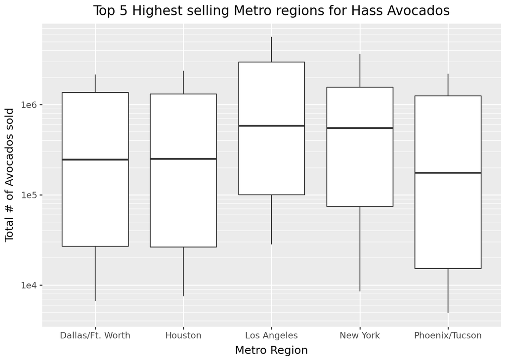

```python
# figure out the 5 highest metros
metros = avocado_clean[avocado_clean["geo_type"] == "metro"][["total_volume", "geography"]]

#store what the top 5 were
top5 = metros.groupby("geography")["total_volume"].mean().nlargest(5).index.tolist()

top5_df = metros[metros["geography"].isin(top5)]

(ggplot(top5_df, aes(x="geography", y="total_volume"))
+ geom_boxplot()
+ scale_y_log10()
+ labs(
    title="Top 5 Highest selling Metro regions for Hass Avocados",
    x="Metro Region",
    y="Total # of Avocados sold"
))
# then for those, boxplots
```

**6. From your cleaned data set, create a data set with only these California regions and answer the following questions about these California regions only.**

```python
california = avocado_clean[avocado_clean["geography"].isin(["Los Angeles", "San Diego", "Sacramento", "San Francisco"])]
california
```

|  | date | average_price | total_volume | small-hass | large-hass | xlarge-hass | total_bags | small_bags | large_bags | xlarge_bags | type | year | geography | major_region5 | month | day | geo_type |
| --- | --- | --- | --- | --- | --- | --- | --- | --- | --- | --- | --- | --- | --- | --- | --- | --- | --- |
| 44 | 2015-01-04 | 0.85 | 2682159.95 | 1837999.65 | 524430.47 | 64225.78 | 255504.05 | 215571.80 | 36981.72 | 2950.53 | conventional | 2015 | Los Angeles | West | 1 | 4 | metro |
| 45 | 2015-01-04 | 1.25 | 54495.54 | 47721.51 | 1723.40 | 0.00 | 5050.63 | 5050.63 | 0.00 | 0.00 | organic | 2015 | Los Angeles | West | 1 | 4 | metro |
| 80 | 2015-01-04 | 1.05 | 430138.88 | 110693.69 | 270107.61 | 9737.50 | 39600.08 | 39600.08 | 0.00 | 0.00 | conventional | 2015 | Sacramento | West | 1 | 4 | metro |
| 81 | 2015-01-04 | 1.33 | 9213.49 | 3727.52 | 4327.52 | 0.00 | 1158.45 | 1158.45 | 0.00 | 0.00 | organic | 2015 | Sacramento | West | 1 | 4 | metro |
| 82 | 2015-01-04 | 0.94 | 461607.33 | 244152.26 | 165299.33 | 15302.75 | 36852.99 | 30884.29 | 5595.00 | 373.70 | conventional | 2015 | San Diego | West | 1 | 4 | metro |
| ... | ... | ... | ... | ... | ... | ... | ... | ... | ... | ... | ... | ... | ... | ... | ... | ... | ... |
| 33018 | 2020-11-29 | 1.43 | 23531.38 | 3303.69 | 2057.03 | 0.00 | 18170.66 | 18144.54 | 26.12 | 0.00 | organic | 2020 | Sacramento | West | 11 | 29 | metro |
| 33019 | 2020-11-29 | 1.12 | 469356.72 | 104509.99 | 19988.45 | 7210.47 | 337647.81 | 189341.36 | 127701.64 | 20604.81 | conventional | 2020 | San Diego | West | 11 | 29 | metro |
| 33020 | 2020-11-29 | 1.95 | 25799.95 | 894.63 | 838.11 | 0.00 | 24067.21 | 9691.46 | 14375.75 | 0.00 | organic | 2020 | San Diego | West | 11 | 29 | metro |
| 33021 | 2020-11-29 | 1.50 | 644141.37 | 128555.43 | 136718.24 | 5597.21 | 373270.49 | 159276.65 | 207760.32 | 6233.52 | conventional | 2020 | San Francisco | West | 11 | 29 | metro |
| 33022 | 2020-11-29 | 1.87 | 59527.02 | 2815.23 | 4542.30 | 0.00 | 52169.49 | 52034.33 | 135.16 | 0.00 | organic | 2020 | San Francisco | West | 11 | 29 | metro |

2448 rows × 17 columns

**7. In which California regions is the price of organic versus conventional avocados most different? Support your answer with a few summary statistics AND a visualization.**

```python
# each row is unquely identified by date and geography, with one column for conventional price and organic price
ca_with_dates = california.pivot(index=["date", "geography"], columns="type", values = "average_price")
ca_with_dates.reset_index(inplace=True)
ca_with_dates["price_diff"] = ca_with_dates["organic"] - ca_with_dates["conventional"]

# for each region, report the price diffs
summary = ca_with_dates.groupby("geography")["price_diff"].agg(["mean", "std", "min", "max"])
summary.reset_index(inplace=True)
```

```python
summary
```

|  | geography | mean | std | min | max |
| --- | --- | --- | --- | --- | --- |
| 0 | Los Angeles | 0.527778 | 0.188143 | 0.07 | 1.21 |
| 1 | Sacramento | 0.578497 | 0.270029 | -0.09 | 1.43 |
| 2 | San Diego | 0.684510 | 0.211286 | 0.20 | 1.41 |
| 3 | San Francisco | 0.718954 | 0.333801 | 0.02 | 1.59 |

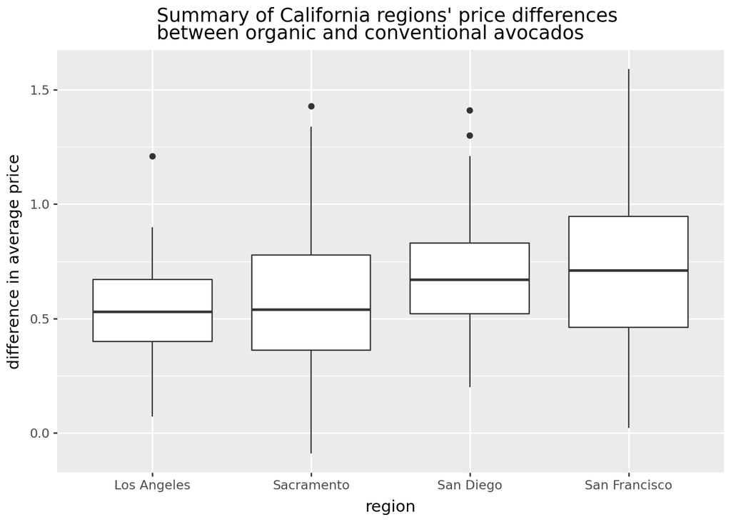

```python
(ggplot(ca_with_dates, aes(x="geography", y = "price_diff")) + geom_boxplot() + scale_y_continuous()
+ labs(
    title="Summary of California regions' price differences \nbetween organic and conventional avocados",
    x='region',
    y="difference in average price"
))
```

**8. The following plot shows, for all four California regions, the proportion of the average Hass avocado sales that are small, large, or extra large; conventional vs. organic. Recreate the plot; you do not have to replicate the exact finishing touches - e.g., color, theme - but your plot should resemble the content of this plot.**

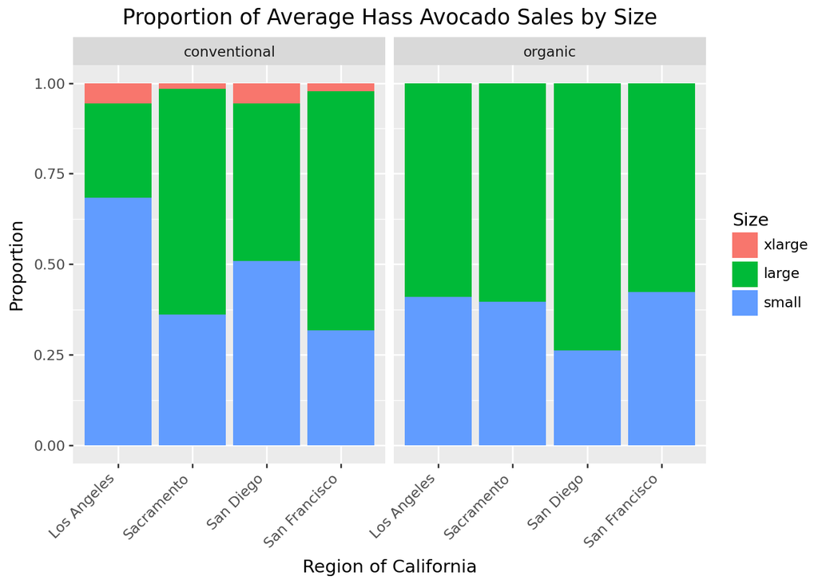

```python
# grouped by ca region, for each region need to average the total volume
california["total_sizes"] = california["small-hass"] + california["large-hass"] + california["xlarge-hass"]

sizes = california.groupby(["geography", "type"])[["small-hass", "large-hass", "xlarge-hass", "total_sizes"]].mean()
sizes.reset_index(inplace=True)

sizes["small"] = sizes["small-hass"] / sizes["total_sizes"]
sizes["large"] = sizes["large-hass"] / sizes["total_sizes"]
sizes["xlarge"] = sizes["xlarge-hass"] / sizes["total_sizes"]



# melt the size columsn into their own column, value is the proportion
prop_long = sizes.melt(
    id_vars=["geography","type"],
    value_vars=["small","large","xlarge"],
    var_name="size",
    value_name="prop"
)

order = ["xlarge","large","small"]
prop_long["size"] = pd.Categorical(prop_long["size"], categories=order, ordered=True)

(ggplot(prop_long, aes(x="geography", y="prop", fill="size")) + geom_col()
+ scale_fill_discrete(limits=order)
+ facet_wrap("~ type")
+ labs(
    title="Proportion of Average Hass Avocado Sales by Size",
    x="Region of California",
    y="Proportion",
    fill="Size"
)
+ theme(axis_text_x=element_text(rotation=45, ha='right')))
```

**Comparing with housing prices in California**

```
       geography  avg_home_price
0    Los Angeles          650000
1      San Diego          600000
2     Sacramento          400000
3  San Francisco         1200000
```

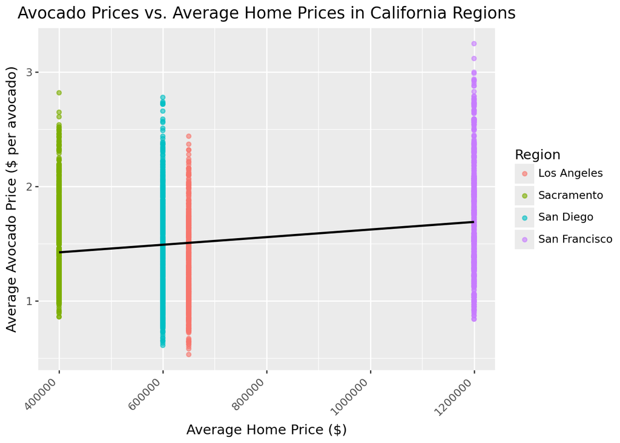

```python
housing = pd.DataFrame({
    "geography": ["Los Angeles", "San Diego", "Sacramento", "San Francisco"],
    "avg_home_price": [650000, 600000, 400000, 1200000]
})

print(housing)

avo_and_housing = pd.merge(left=california, right=housing, on=["geography"])

(ggplot(avo_and_housing, aes(x="avg_home_price", y="average_price", color="geography"))
    + geom_point(alpha=0.6)
    + geom_smooth(method="lm", se=False, color="black")
    + theme(axis_text_x=element_text(rotation=45, hjust=1))
    + labs(
        title="Avocado Prices vs. Average Home Prices in California Regions",
        x="Average Home Price ($)",
        y="Average Avocado Price ($ per avocado)",
        color="Region"
    )
)
```

Each vertical group represents one of the four California regions. The trend line shows a slight positive relationship between average home prices and avocado prices –> higher-priced housing markets also tend to have higher avocado prices. This suggests that the avocado toast effect is more a reflection of general cost-of-living differences rather than causation.